### Prétraitemnt

```python
def detect_and_treat_outliers(df, column):
    # Calcul des quartiles
    Q1 = df[column].quantile(0.25)
    Q3 = df[column].quantile(0.75)
    IQR = Q3 - Q1

    # Définition des bornes
    lower_bound = Q1 - 1.5 * IQR
    upper_bound = Q3 + 1.5 * IQR

    # Détection des valeurs aberrantes
    outliers = df[(df[column] < lower_bound) | (df[column] > upper_bound)]

    # Affichage des valeurs aberrantes
    print(f"Valeurs aberrantes détectées pour {column} :")
    print(outliers)

    # Traitement : Option 2 (remplacement)
    df.loc[df[column] < lower_bound, column] = lower_bound
    df.loc[df[column] > upper_bound, column] = upper_bound

    return df

# Utilisation de la fonction pour d'autres colonnes
df = detect_and_treat_outliers(df, 'Montant de découvert')
df = detect_and_treat_outliers(df, 'Encours crédit à la consommation')
df = detect_and_treat_outliers(df, 'Revenu annuel')
# Ajoute d'autres colonnes si nécessaire
```

[output not shown]

[output cut: 513 more lines]

```python
### Selection de variables pertinentes
from scipy.stats import chi2_contingency

# Sélectionner les variables catégorielles
categorical_vars = df.select_dtypes(include=['object', 'category']).columns

# Dictionnaire pour stocker les résultats
chi2_results = {}

# Appliquer le test du chi-carré à chaque variable catégorielle
for var in categorical_vars:
    contingency_table = pd.crosstab(df[var], df['Variable cible'])
    chi2, p, dof, expected = chi2_contingency(contingency_table)
    chi2_results[var] = {'chi2': chi2, 'p_value': p, 'dof': dof}

# Affichage des résultats
results_df = pd.DataFrame(chi2_results).T
print(results_df)
```

```
                                 chi2   p_value  dof
Sexe                         0.910353  0.340021  1.0
Crédit immobilier (oui/non)  0.355698  0.550905  1.0
Compte épargne (oui/non)     0.000000  1.000000  1.0
Compte placement (oui/non)   4.773858  0.028895  1.0
Compte courant (oui/non)     0.175234  0.675501  1.0
Carte (oui/non)              1.154235  0.282664  1.0
Assurance (oui/non)          1.216967  0.269957  1.0
Profession                   6.132675  0.189457  4.0
Découvert (oui/non)          0.000000  1.000000  0.0
Flux créditeur               0.470704  0.492663  1.0
Flux débiteur                0.000000  1.000000  1.0
```

### 3. Interprétation des Résultats

Voici comment interpréter les résultats :

- **Statistique Chi-Carré (chi2)** : Cette valeur mesure l'écart entre les fréquences observées et les fréquences attendues. Une valeur plus élevée indique une plus grande déviation des fréquences observées par rapport aux fréquences attendues.
- **p-value** : Si la p-value est inférieure à un seuil (souvent 0.05), tu peux rejeter l'hypothèse nulle. Cela signifie qu'il existe une association significative entre la variable catégorielle et la variable cible.
- **degrés de liberté (dof)** : C'est un paramètre qui dépend du nombre de catégories dans les variables. Il est utile pour interpréter la valeur p.

### Exemple d'Interprétation

Imaginons que tu as obtenu les résultats suivants pour une variable catégorielle :

| Variable | chi2 | p_value | dof |
| --- | --- | --- | --- |
| Profession | 10.23 | 0.001 | 4 |
| Découvert | 5.67 | 0.45 | 1 |
| Carte | 3.50 | 0.061 | 1 |

- **Profession** : La p-value de 0.001 est inférieure à 0.05, ce qui signifie qu'il y a une association significative entre la profession et la décision de souscrire à un crédit à la consommation. Cela pourrait indiquer que certains métiers sont plus enclins à souscrire.
- **Découvert** : Avec une p-value de 0.45, il n'y a pas de relation significative entre la possession d'un découvert et la souscription au crédit, ce qui suggère que le statut de découvert n'influence pas la décision de souscrire.
- **Carte** : La p-value de 0.061 est proche de 0.05, ce qui pourrait indiquer une tendance mais pas une signification statistique forte. Cela pourrait mériter une exploration plus approfondie.

### Conclusion

L'application du test du chi-carré à toutes les variables catégorielles permet de mieux comprendre quelles variables sont significativement liées à la variable cible. Cela peut aider à sélectionner les variables pertinentes pour la modélisation ou l'analyse ultérieure. Si tu as besoin d'une aide supplémentaire ou d'une exploration plus détaillée, n'hésite pas à demander !

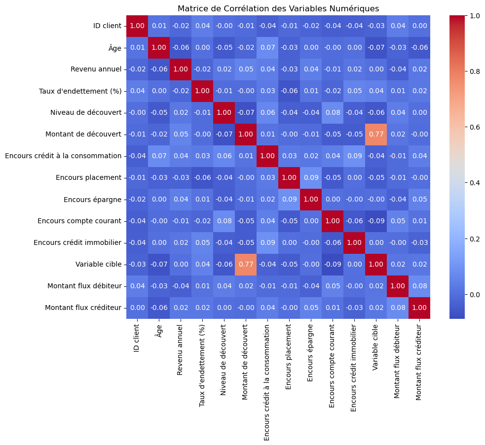

```python
import pandas as pd
import seaborn as sns
import matplotlib.pyplot as plt

# Supposons que df est déjà défini et contient toutes les données

# Filtrer uniquement les colonnes numériques (float et int)
numerical_df = df.select_dtypes(include=['float', 'int'])

# Calculer la matrice de corrélation
corr = numerical_df.corr()

# Créer la heatmap
plt.figure(figsize=(10, 8))
sns.heatmap(corr, annot=True, fmt=".2f", cmap='coolwarm', square=True)
plt.title('Matrice de Corrélation des Variables Numériques')
plt.show()
```

Pour analyser la relation entre des variables numériques, tu peux utiliser différents tests de corrélation, dont le plus courant est le coefficient de corrélation de Pearson. Voici comment procéder :

### 1. Calculer le Coefficient de Corrélation de Pearson

Le coefficient de corrélation de Pearson mesure la force et la direction d'une relation linéaire entre deux variables continues. Il varie de -1 à 1 :

- **1** : Corrélation positive parfaite.
- **0** : Pas de corrélation.
- **-1** : Corrélation négative parfaite.

### 3. Interprétation des Résultats

#### a. Coefficient de Corrélation

- **Positive (proche de 1)** : Si le coefficient est, par exemple, 0.8, cela indique qu'il existe une forte corrélation positive entre `Revenu annuel` et `Taux d'endettement`. Cela signifie qu'à mesure que le revenu augmente, le taux d'endettement a tendance à augmenter également.
- **Négative (proche de -1)** : Un coefficient de -0.5 indiquerait une corrélation négative modérée. Par exemple, cela pourrait signifier qu'un revenu plus élevé est associé à un taux d'endettement plus faible.
- **Aucune Corrélation (proche de 0)** : Un coefficient de 0 indique qu'il n'y a pas de relation linéaire entre les variables.

#### b. Visualisation

La pertinence d'une variable par rapport à une variable cible peut être déterminée par plusieurs critères, surtout lorsque tu utilises des coefficients de corrélation. Voici des indications sur quand on peut considérer qu'une variable est pertinente :

### 1. Coefficient de Corrélation

- **Coefficients Absolus Élevés** : Un coefficient de corrélation absolu supérieur à 0.5 (ou 0.7) est souvent considéré comme un signe de pertinence significative. Par exemple :
  - **0.8 à 1** : Forte corrélation positive. La variable est très pertinente.
  - **0.5 à 0.8** : Corrélation modérée. La variable peut être pertinente mais doit être analysée dans le contexte.
  - **-0.5 à -0.8** : Corrélation négative modérée. La variable peut aussi être pertinente.
  - **Proche de 0** : Indique peu ou pas de relation linéaire, donc la variable est probablement moins pertinente.

### 2. Tests Statistiques

- **Test de Signification** : Si tu effectues des tests (comme le test de chi-carré pour les variables catégorielles), une p-value inférieure à 0.05 indique que la variable est statistiquement significative et, par conséquent, pertinente.

### 3. Importance dans un Modèle

- **Modèles Prédictifs** : Lors de l'utilisation de modèles d'apprentissage automatique (comme la régression logistique ou les forêts aléatoires), l'importance des caractéristiques peut être évaluée. Une variable avec une importance élevée dans un modèle indique qu'elle contribue significativement aux prédictions.

### 4. Visualisation

- **Graphiques** : Des visualisations (comme des scatter plots pour les variables continues ou des box plots pour les variables catégorielles) peuvent révéler des tendances ou des regroupements qui indiquent la pertinence d'une variable.

### 5. Contextualisation

- **Pertinence Contextuelle** : Même si les analyses statistiques montrent qu'une variable est pertinente, il est essentiel de la considérer dans le contexte de l'analyse. Par exemple, une variable peut avoir un lien statistique fort, mais ne pas avoir de sens dans le contexte métier ou économique.

### Conclusion

On peut dire qu'une variable est pertinente par rapport à la variable cible si :

- Son coefficient de corrélation est significativement éloigné de 0 (en général, au-delà de ±0.5).
- Les tests statistiques montrent une association significative.
- Elle a une importance élevée dans les modèles prédictifs.
- Les visualisations indiquent des relations claires.
- Elle fait sens dans le contexte de l'analyse.

Si tu as besoin d'exemples concrets ou d'analyses spécifiques, fais-le moi savoir !

[output not shown]

### 4. Autres Tests de Corrélation

Si tes données ne respectent pas les hypothèses de normalité, tu peux utiliser d'autres tests de corrélation :

- **Corrélation de Spearman** : Utilisée pour des données ordinales ou lorsque les données ne suivent pas une distribution normale.

```
spearman_corr = df[['Revenu annuel', 'Taux d\'endettement']].corr(method='spearman')
print(spearman_corr)
```

- **Corrélation de Kendall** : Une autre alternative pour des données ordinales ou non paramétriques.

### Conclusion

Le test de corrélation est essentiel pour comprendre les relations entre des variables numériques. En utilisant le coefficient de Pearson, tu peux obtenir des insights précieux sur la manière dont les différentes caractéristiques interagissent. Si tu as d'autres questions ou si tu souhaites approfondir un aspect particulier, fais-le moi savoir !

```python
df.columns
```

```
Index(['ID client', 'Âge', 'Sexe', 'Revenu annuel', 'Taux d'endettement (%)',
       'Niveau de découvert', 'Montant de découvert',
       'Crédit immobilier (oui/non)', 'Encours crédit à la consommation',
       'Encours placement', 'Encours épargne', 'Encours compte courant',
       'Encours crédit immobilier', 'Compte épargne (oui/non)',
       'Compte placement (oui/non)', 'Compte courant (oui/non)',
       'Carte (oui/non)', 'Assurance (oui/non)', 'Profession',
       'Variable cible', 'Découvert (oui/non)', 'Flux créditeur',
       'Flux débiteur', 'Montant flux débiteur', 'Montant flux créditeur'],
      dtype='object')
```

```python
## Construction du modele
```

```python
import pandas as pd
from sklearn.preprocessing import LabelEncoder
# Liste des colonnes catégorielles
categorical_columns = df.select_dtypes(include=['object']).columns.tolist()
# Initialiser le LabelEncoder
label_encoder = LabelEncoder()

# Appliquer le Label Encoding à chaque colonne catégorielle
for col in categorical_columns:
    df[col] = label_encoder.fit_transform(df[col])
```

```python
df.head()
```

|  | ID client | Âge | Sexe | Revenu annuel | Taux d'endettement (%) | Niveau de découvert | Montant de découvert | Crédit immobilier (oui/non) | Encours crédit à la consommation | Encours placement | ... | Compte courant (oui/non) | Carte (oui/non) | Assurance (oui/non) | Profession | Variable cible | Découvert (oui/non) | Flux créditeur | Flux débiteur | Montant flux débiteur | Montant flux créditeur |
| --- | --- | --- | --- | --- | --- | --- | --- | --- | --- | --- | --- | --- | --- | --- | --- | --- | --- | --- | --- | --- | --- |
| 0 | 1 | 35.0 | 0 | 97939.0 | 47 | 2224 | 350 | 1 | 17207.0 | 2040 | ... | 0 | 0 | 1 | 1 | 0 | 0 | 1 | 1 | 453 | 1392 |
| 1 | 2 | 36.0 | 0 | 80740.0 | 36 | 4385 | 464 | 1 | 15704.0 | 2894 | ... | 0 | 0 | 0 | 2 | 0 | 0 | 1 | 1 | 616 | 382 |
| 2 | 3 | 60.0 | 0 | 85128.0 | 43 | 4221 | 183 | 0 | 22282.0 | 3957 | ... | 0 | 1 | 1 | 0 | 0 | 0 | 1 | 1 | 1880 | 1340 |
| 3 | 4 | 42.0 | 1 | 72015.0 | 48 | 5 | 297 | 1 | 788.0 | 41962 | ... | 1 | 0 | 1 | 3 | 0 | 0 | 1 | 1 | 172 | 1344 |
| 4 | 5 | 46.0 | 1 | 53258.0 | 43 | 2752 | 275 | 0 | 4859.0 | 1913 | ... | 1 | 1 | 0 | 2 | 0 | 0 | 0 | 1 | 1969 | 1035 |

5 rows × 25 columns

```python
from sklearn.preprocessing import OneHotEncoder
from sklearn.preprocessing import StandardScaler
from sklearn.compose import ColumnTransformer
from sklearn.pipeline import Pipeline
from sklearn.model_selection import train_test_split
# Séparer les variables continues et catégorielles
y = df['Variable cible']
X = df.drop('Variable cible', axis=1)
# Séparer les données
X_train, X_test, y_train, y_test = train_test_split(X, y, test_size=0.2, random_state=42, stratify=y)

# Liste des colonnes continues et catégorielles
continues = X.select_dtypes(include=['float64', 'int']).columns.tolist()
categorical = X.select_dtypes(include=['object']).columns.tolist()

# Pipeline pour transformer les données
preprocessor = ColumnTransformer(
    transformers=[
        ('num', StandardScaler(), continues),
        ('cat', OneHotEncoder(), categorical)
    ])

X_processed = preprocessor.fit_transform(X)
```

```python
from sklearn.model_selection import train_test_split
from sklearn.linear_model import LogisticRegression
from sklearn.tree import DecisionTreeClassifier
from sklearn.ensemble import RandomForestClassifier, GradientBoostingClassifier
from sklearn.metrics import classification_report, confusion_matrix

# Liste des modèles
models = {
    'Régression Logistique': LogisticRegression(),
    'Arbre de Décision': DecisionTreeClassifier(),
    'Forêt Aléatoire': RandomForestClassifier(),
    'Gradient Boosting': GradientBoostingClassifier()
}

results = []

# Entraîner et évaluer chaque modèle
for name, model in models.items():
    model.fit(X_train, y_train)

    # Prédictions
    y_train_pred = model.predict(X_train)
    y_test_pred = model.predict(X_test)

    # Évaluation sur les données d'entraînement
    train_report = classification_report(y_train, y_train_pred, output_dict=True)

    # Évaluation sur les données de test
    test_report = classification_report(y_test, y_test_pred, output_dict=True)

    results.append({
        'Modèle': name,
        'Train Precision': train_report['1']['precision'],
        'Train Recall': train_report['1']['recall'],
        'Train F1-Score': train_report['1']['f1-score'],
        'Test Precision': test_report['1']['precision'],
        'Test Recall': test_report['1']['recall'],
        'Test F1-Score': test_report['1']['f1-score']
    })

results_df = pd.DataFrame(results)
results_df.head()
```

|  | Modèle | Train Precision | Train Recall | Train F1-Score | Test Precision | Test Recall | Test F1-Score |
| --- | --- | --- | --- | --- | --- | --- | --- |
| 0 | Régression Logistique | 0.948718 | 0.925 | 0.936709 | 0.75 | 0.9 | 0.818182 |
| 1 | Arbre de Décision | 1.000000 | 1.000 | 1.000000 | 1.00 | 1.0 | 1.000000 |
| 2 | Forêt Aléatoire | 1.000000 | 1.000 | 1.000000 | 1.00 | 1.0 | 1.000000 |
| 3 | Gradient Boosting | 1.000000 | 1.000 | 1.000000 | 1.00 | 1.0 | 1.000000 |

```python
### Données équilibrer
```

```python
from imblearn.over_sampling import SMOTE

smote = SMOTE(random_state=42)
X_resampled, y_resampled = smote.fit_resample(X, y)
```

[output not shown]

[output cut: 59 more lines]

```python
# Séparation des données rééquilibrées
X_train_res, X_test_res, y_train_res, y_test_res = train_test_split(X_resampled, y_resampled, test_size=0.2, random_state=42)
```